# Data and Measurement

# Tutorial 5

In this tutorial, we will utilize the “SAQ.sav” dataset. This dataset comprises 23 variables measured on a 5-point Likert scale and includes data from 2,571 participants. The items included are:

1. Statistics makes me cry.
2. My friends will think I’m stupid for not being able to cope with SPSS.
3. Standard deviations excite me.
4. I dream that Pearson is attacking me with correlation coefficients.
5. I don’t understand statistics.
6. I have little experience of computers.
7. All computers hate me.
8. I have never been good at mathematics.
9. My friends are better at statistics than me.
10. Computers are useful only for playing games.
11. I did badly at mathematics at school.
12. People try to tell you that SPSS makes statistics easier to understand but it doesn’t.
13. I worry that I will cause irreparable damage because of my incompetenece with computers.
14. Computers have minds of their own and deliberately go wrong whenever I use them.
15. Computers are out to get me.
16. I weep openly at the mention of central tendency.
17. I slip into a coma whenever I see an equation.
18. SPSS always crashes when I try to use it.
19. Everybody looks at me when I use SPSS.
20. I can’t sleep for thoughts of eigen vectors.
21. I wake up under my duvet thinking that I am trapped under a normal distribution.
22. My friends are better at SPSS than I am.
23. If I’m good at statistics my friends will think I’m a nerd.

### Exercise

1. Load the data to the environment. If you use read.spss function set the use.value.labels argument to FALSE to avoid converting numerical variables (with value labels) to factors as the functions we will use (alpha() and fa()) require numerical variables.

```r
library(foreign)
saq_df <- read.spss("~/Downloads/DS5 SPSS Files/SAQ.sav",
    to.data.frame = TRUE,
    use.value.labels = FALSE)
```

2. Explore the dataset. Suggestion: Give it a try to describe() function from psych package.

```r
sum(is.na(saq_df))
```

```
## [1] 0
```

```r
psych::describe(saq_df[1:5])  # Displaying only the first 5 variables to avoid overwhelming the document with excessive information.
```

|  | vars | n | mean | sd | median | trimmed | mad | min | max | range | skew | kurtosis | se |
| --- | --- | --- | --- | --- | --- | --- | --- | --- | --- | --- | --- | --- | --- |
| Question_01 | 1 | 2571 | 2.374173 | 0.8280221 | 2 | 2.336898 | 0.0000 | 1 | 5 | 4 | 0.6545600 | 0.6055246 | 0.0163302 |
| Question_02 | 2 | 2571 | 1.623493 | 0.8510787 | 1 | 1.460865 | 0.0000 | 1 | 5 | 4 | 1.4876780 | 2.0367054 | 0.0167849 |
| Question_03 | 3 | 2571 | 2.585375 | 1.0750097 | 3 | 2.569762 | 1.4826 | 1 | 5 | 4 | 0.0894099 | -0.7801429 | 0.0212012 |
| Question_04 | 4 | 2571 | 2.786075 | 0.9485482 | 3 | 2.741857 | 1.4826 | 1 | 5 | 4 | 0.3851799 | -0.2878337 | 0.0187072 |
| Question_05 | 5 | 2571 | 2.722287 | 0.9646904 | 3 | 2.675741 | 1.4826 | 1 | 5 | 4 | 0.4556425 | -0.4418064 | 0.0190255 |

3. Compute the correlation matrix (Remember Tutorial 3 - Exercise 2?), and in round correlations to two digits after the decimal point.

```r
Rmatrix <- cor(saq_df)
print(round(Rmatrix[1:5,
    1:5], digits = 2))  # Displaying only the first 5 rows and columns to avoid overwhelming the document with excessive information.
```

```
##             Question_01 Question_02 Question_03 Question_04 Question_05
## Question_01        1.00       -0.10       -0.34        0.44        0.40
## Question_02       -0.10        1.00        0.32       -0.11       -0.12
## Question_03       -0.34        0.32        1.00       -0.38       -0.31
## Question_04        0.44       -0.11       -0.38        1.00        0.40
## Question_05        0.40       -0.12       -0.31        0.40        1.00
```

4. We can also plot correlation matrices by using the cor.plot() function from the psych package. Try this out -I suggest you set the “upper”argument to FALSE to get a better representation - and see if it matches your results from the previous exercise.

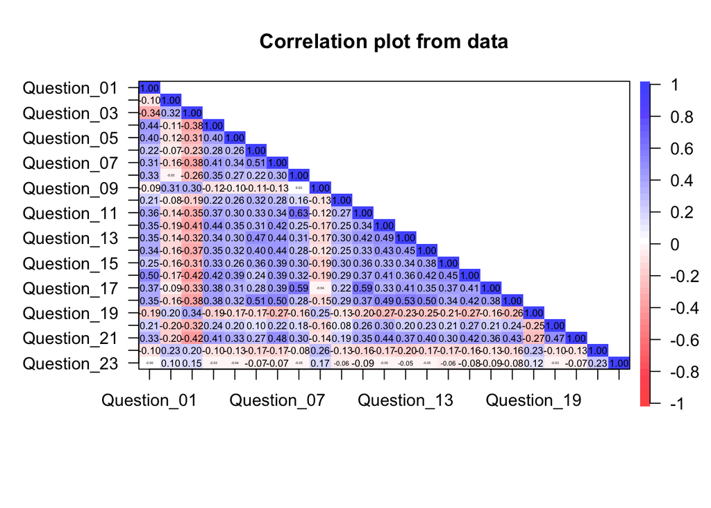

```r
# Plot R matrix
psych::cor.plot(saq_df,
    upper = FALSE)
```

5. Even if you enlarge the diagram, discerning the variable names on the x-axis remains challenging because we have many variables and long variable names. Therefore, change the variable names in your data frame from “Question_1”, “Question_2” etc. to “q1”, “q2” etc. You can accomplish this using the names() or colnames() functions together with the gsub() function. Then display the correlation matrix again and see if you can find clusters of variables that exhibit stronger correlations among themselves compared to other groups of variables.

```r
# Rename variables
colnames(saq_df) <- gsub("Question_",
    "q", colnames(saq_df))
print(colnames(saq_df))
```

```
##  [1] "q01" "q02" "q03" "q04" "q05" "q06" "q07" "q08" "q09" "q10" "q11" "q12"
## [13] "q13" "q14" "q15" "q16" "q17" "q18" "q19" "q20" "q21" "q22" "q23"
```

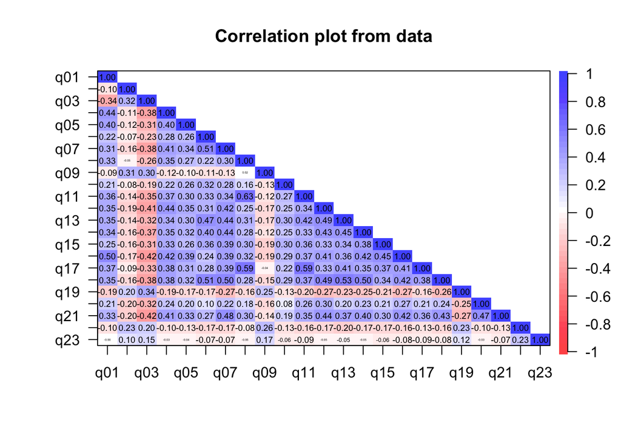

```r
psych::cor.plot(saq_df,
    upper = FALSE)
```

6. According to Field (2019), items 2, 9, 19, 22 and 23 are measuring a specific type of fear, namely, fear of peer evaluation. Create a new dataframe consisting only of these five items.

```r
fear_peer <- saq_df[,
    c(2, 9, 19, 22, 23)]
```

7. Find the cronbach’s alpha using the alpha() function from psych package. Note: ggplot2 also has a function called alpha and if you’ve loaded ggplot2, the alpha function in ggplot2 may be called instead. to avoid this call the function using psych::alpha().

```r
psych::alpha(fear_peer)
```

```
##
## Reliability analysis
## Call: psych::alpha(x = fear_peer)
##
##   raw_alpha std.alpha G6(smc) average_r S/N   ase mean   sd median_r
##       0.57      0.57    0.53      0.21 1.3 0.013  2.6 0.65     0.23
##
##     95% confidence boundaries
##          lower alpha upper
## Feldt     0.54  0.57   0.6
## Duhachek  0.54  0.57   0.6
##
##  Reliability if an item is dropped:
##     raw_alpha std.alpha G6(smc) average_r  S/N alpha se  var.r med.r
## q02      0.52      0.52    0.45      0.21 1.07    0.015 0.0028  0.23
## q09      0.48      0.48    0.41      0.19 0.92    0.017 0.0036  0.22
## q19      0.52      0.53    0.46      0.22 1.11    0.015 0.0055  0.23
## q22      0.49      0.49    0.43      0.19 0.96    0.016 0.0065  0.19
## q23      0.56      0.57    0.50      0.25 1.32    0.014 0.0014  0.24
##
##  Item statistics
##        n raw.r std.r r.cor r.drop mean   sd
## q02 2571  0.56  0.61  0.45   0.34  1.6 0.85
## q09 2571  0.70  0.66  0.53   0.39  2.8 1.26
## q19 2571  0.61  0.60  0.42   0.32  2.3 1.10
## q22 2571  0.64  0.64  0.50   0.38  2.9 1.04
## q23 2571  0.53  0.53  0.31   0.24  3.4 1.04
##
## Non missing response frequency for each item
##        1    2    3    4    5 miss
## q02 0.56 0.31 0.08 0.04 0.01    0
## q09 0.20 0.20 0.23 0.28 0.08    0
## q19 0.29 0.33 0.22 0.15 0.02    0
## q22 0.10 0.26 0.34 0.26 0.05    0
## q23 0.06 0.12 0.27 0.42 0.12    0
```

8. Interpret the results.
- We often focus on the value of raw_alpha, which is suitable when all items share similar scales or measurement units. A raw_alpha value of ≥ 0.7 or 0.8 indicates good reliability (Kline, 1999).
- Std.alpha is the standardized alpha computed based on correlations and is typically similar to raw_alpha.(unless when items have different scales or measurement units).
- Average_r represents the mean inter-item correlation used in alpha computation, while median_r denotes the median inter-item correlation.
- The mean refers to the scale mean, representing the mean of all individual means.
- In the section “Reliability if an Item is Dropped”, each row corresponds to an item and displays its associated raw alpha, which reflects the overall alpha when that specific item is dropped. For instance, the first row pertains to q02. If dropped, the overall alpha reduces to 0.52, indicating decreased reliability.We evaluate if any raw alpha value exceeds the overall alpha of 0.57. If so, dropping that item would increase the overall alpha of the scale. Other columns in this section illustrate how other statistics would change if the item were dropped.
- In the “Item statistics” part, the correlation between the items and the total score from the scale iare shown.
- In the last part of the output, the frequency table illustrates the percentage of observations per response category and item.For a 5-point scale, for example, it shows the percentage of answers that were rated 1, 2, 3, 4 or 5.This helps to assess the distribution of answers and the uniformity among the participants.